# Exoplanet Observability: Finding Clean, Nearby Targets

Author

John Frasier

## Specific Question

Which candidate exoplanets present the greatest observational feasibility for atmospheric characterization based on distance, host-star brightness, and transit depth, and how does Gaia DR3 astrometric screening filter out binary star contamination?

## Summary of Approach

Even if an exoplanet has Earth-like physical proportions and a temperate climate, it has limited scientific value if current telescopes cannot detect or characterize its atmosphere. This analysis reviews the known exoplanet catalog for practical observability using three operational criteria:

- **Proximity:** Restricting candidates to systems within 100 parsecs ( d <= 100 pc).
- **Transit Detectability:** Requiring a confirmed, non-zero transit depth (pl_trandep > 0) for transmission spectroscopy.
- **Host-Star Stability:** Cross-referencing host stars with the European Space Agency (ESA) Gaia DR3 catalog to identify clean single stars (RUWE <= 1.4) and flag binary systems that distort measurements.

## Data Quality and Setup

```r
# Load required libraries
library(dplyr)
library(ggplot2)
library(httr)

# Step 1: Ingest NASA table and check completeness
target_paths <- c(
  "data/processed/nasa_clean.csv",
  "../../data/processed/nasa_clean.csv",
  "data/raw/nasa_pscomppars_2026-09-19.csv",
  "../../data/raw/nasa_pscomppars_2026-09-19.csv",
  "nasa_clean.csv",
  "../../nasa_clean.csv"
)

data_path <- target_paths[file.exists(target_paths)][1]
if (is.na(data_path)) {
  stop("There was a problem loading the NASA dataset.")
}

df <- read.csv(data_path, stringsAsFactors = FALSE)
total_planets <- nrow(df)

# Evaluate missingness for key observability variables
obs_cols <- c("sy_dist", "pl_trandep")
missing_obs_pct <- (colSums(is.na(df[obs_cols])) / total_planets) * 100
round(missing_obs_pct, 2)
```

```
   sy_dist pl_trandep
      0.44      28.98
```

```r
# Calculate percentage of planets with valid Gaia IDs
missing_gaia <- sum(is.na(df$gaia_dr3_id) | df$gaia_dr3_id == "")
pct_has_gaia <- ((total_planets - missing_gaia) / total_planets) * 100
cat("Planets with Gaia ID:", round(pct_has_gaia, 2), "%\n")
```

```
Planets with Gaia ID: 93.86 %
```

System distance is missing in only 0.44% of records, demonstrating strong spatial completeness. Transit depth is missing in 28.98% of rows. This missing data is expected, as non-transiting detection methods like radial velocity do not produce photometric transit dips. Additionally, 93.86% (n = 5,975) of confirmed hosts have valid Gaia identifiers, ensuring astrometric cross-matching does not induce severe sample attrition.

## Candidate Selection and Host Star Deduplication

Because multi-planet systems (like TRAPPIST-1) have multiple planets around a single star, counting rows directly would impact the statistics. To address this, I filtered for nearby transiting worlds and then counted unique host stars.

```r
# Step 2: Remove string prefix so only the numeric source ID remains
df$gaia_source_id <- gsub("^Gaia DR3 ", "", trimws(df$gaia_dr3_id))

# Filter for transiting planets within 100 parsecs
candidate_planets <- df %>%
  filter(!is.na(sy_dist) & sy_dist <= 100 &
           !is.na(pl_trandep) & pl_trandep > 0 &
           !is.na(gaia_source_id) & gaia_source_id != "")

# Week 4 feedback: Count only distinct stars so multi-planet systems don't bias stats
unique_hosts <- candidate_planets %>%
  distinct(hostname, .keep_all = TRUE)

cat("Candidate Planets (<= 100 pc):", nrow(candidate_planets), "\n")
```

```
Candidate Planets (<= 100 pc): 528
```

```r
cat("Unique Candidate Host Stars :", nrow(unique_hosts), "\n")
```

```
Unique Candidate Host Stars : 388
```

Filtering retains 528 candidate transiting planets within 100 parsecs. Deduplicating by host star reduces the sample to 388 unique stars, eliminating 140 redundant host entries.

## Programmatic Gaia DR3 Astrometric Query

I queried the ESA Gaia DR3 database to retrieve optical brightness (phot_g_mean_mag) and stellar wobble metrics (RUWE) for the 388 unique host stars.

```r
# Step 3: Check local cache or query Gaia TAP API
gaia_candidates <- c(
  "data/raw/gaia_nearby_hosts.csv",
  "../../data/raw/gaia_nearby_hosts.csv",
  "gaia_nearby_hosts.csv"
)

gaia_file <- gaia_candidates[file.exists(gaia_candidates)][1]
if (is.na(gaia_file)) {
  gaia_file <- if (dir.exists("data/raw")) "data/raw/gaia_nearby_hosts.csv" else if (dir.exists("../../data/raw")) "../../data/raw/gaia_nearby_hosts.csv" else "gaia_nearby_hosts.csv"
}

if (!file.exists(gaia_file)) {
  clean_ids <- unique_hosts$gaia_source_id[grepl("^[0-9]+$", unique_hosts$gaia_source_id)]
  id_list <- paste0("'", clean_ids, "'", collapse = ",")

  query_text <- paste0(
    "SELECT source_id, parallax, phot_g_mean_mag, ruwe ",
    "FROM gaiadr3.gaia_source WHERE source_id IN (", id_list, ")"
  )

  res <- POST(
    url = "https://gea.esac.esa.int/tap-server/tap/sync",
    body = list(REQUEST = "doQuery", LANG = "ADQL", FORMAT = "csv", QUERY = query_text),
    encode = "form",
    timeout(180)
  )

  stopifnot("Gaia TAP API query failed" = status_code(res) == 200)

  gaia_data <- read.csv(text = content(res, as = "text"), colClasses = c("source_id" = "character"))
  write.csv(gaia_data, gaia_file, row.names = FALSE)
} else {
  gaia_data <- read.csv(gaia_file, colClasses = c("source_id" = "character"))
}

# Step 4: Merge Gaia data and classify by RUWE <= 1.4
hosts_clean <- unique_hosts %>%
  select(hostname, gaia_source_id, sy_dist, pl_trandep) %>%
  left_join(gaia_data, by = c("gaia_source_id" = "source_id")) %>%
  mutate(
    star_type = ifelse(ruwe <= 1.4, "Single Star (Clean)", "Disturbed / Binary Star")
  )

cat("Astrometric Star Breakdown:\n")
```

```
Astrometric Star Breakdown:
```

```r
table(hosts_clean$star_type)
```

```
Disturbed / Binary Star     Single Star (Clean)
                     18                     370
```

Out of 388 unique host stars, 370 (95.36%) are confirmed clean, single stars. Eighteen stars (4.64%) display excessive wobble (RUWE > 1.4), indicating unresolved binary companion systems or astrometric disturbance.

## Observational Feasibility Visualizations

I plotted host distance against optical brightness (phot_g_mean_mag). The y-axis is inverted following astronomical convention so brighter stars appear higher on the plot. The high-priority triage window (d <= 35 pc, G <= 12 mag) isolates the immediate solar neighborhood where spectroscopic signal-to-noise is maximized for space platforms (such as JWST), while maintaining a brightness threshold suitable for high-precision ground-based follow-up.

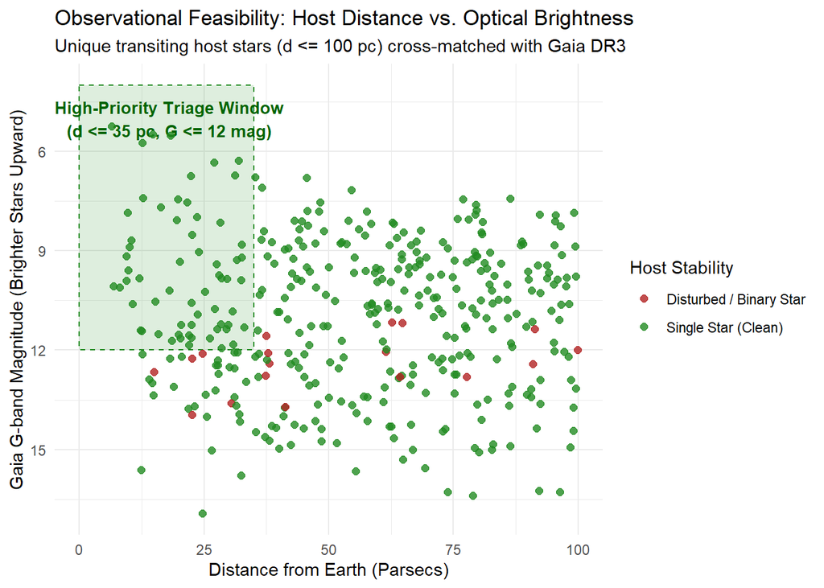

```r
# Step 5: Filter complete cases and generate feasibility plot
plot_data <- hosts_clean %>% filter(!is.na(phot_g_mean_mag) & !is.na(star_type))

fig3 <- ggplot(plot_data, aes(x = sy_dist, y = phot_g_mean_mag, color = star_type)) +
  # Week 5 feedback: Highlight the high-priority triage window directly on the plot
  annotate("rect", xmin = 0, xmax = 35, ymin = 12, ymax = 4,
           fill = "forestgreen", alpha = 0.15, linetype = "dashed", color = "forestgreen") +
  annotate("text", x = 18, y = 5, label = "High-Priority Triage Window\n(d <= 35 pc, G <= 12 mag)",
           fontface = "bold", size = 3.5, color = "darkgreen") +
  geom_point(size = 2, alpha = 0.8) +
  scale_y_reverse() +
  scale_color_manual(values = c("Single Star (Clean)" = "forestgreen",
                                "Disturbed / Binary Star" = "firebrick")) +
  labs(
    title = "Observational Feasibility: Host Distance vs. Optical Brightness",
    subtitle = "Unique transiting host stars (d <= 100 pc) cross-matched with Gaia DR3",
    x = "Distance from Earth (Parsecs)",
    y = "Gaia G-band Magnitude (Brighter Stars Upward)",
    color = "Host Stability"
  ) +
  theme_minimal()

print(fig3)
```

## Planetary Priority Tiers

Joining host stability back to the 528 candidate planets categorizes them into three tiers:

```r
# Step 6: Categorize planets into three operational priority tiers
planets_tiered <- candidate_planets %>%
  left_join(select(hosts_clean, hostname, phot_g_mean_mag, ruwe, star_type), by = "hostname") %>%
  mutate(
    priority_tier = case_when(
      ruwe > 1.4 ~ "Disqualified (Binary Noise)",
      sy_dist <= 35 & phot_g_mean_mag <= 12.0 ~ "Tier 1: Prime Target (Nearby & Bright)",
      TRUE ~ "Tier 2: Secondary Target (Fainter / Farther)"
    )
  )

cat("Planets per Priority Tier:\n")
```

```
Planets per Priority Tier:
```

```r
table(planets_tiered$priority_tier)
```

```
                 Disqualified (Binary Noise)
                                          30
      Tier 1: Prime Target (Nearby & Bright)
                                          88
Tier 2: Secondary Target (Fainter / Farther)
                                         410
```

The resulting distribution shows:

- **Tier 1 (Best Targets):** 88 planets (16.67%)
- **Tier 2 (Secondary Targets):** 410 planets (77.65%)
- **Disqualified Systems:** 30 planets (5.68%)

### Top Candidates (Tier 1)

```r
tier1_distinct_hosts <- planets_tiered %>%
  filter(priority_tier == "Tier 1: Prime Target (Nearby & Bright)") %>%
  distinct(hostname, .keep_all = TRUE) %>%
  select(pl_name, hostname, sy_dist, phot_g_mean_mag, ruwe, pl_trandep) %>%
  arrange(desc(pl_trandep))

knitr::kable(
  head(tier1_distinct_hosts, 5),
  col.names = c("Planet", "Host Star", "Distance (pc)", "Gaia G (mag)", "RUWE", "Transit Depth (%)"),
  digits = 3,
  row.names = FALSE
)
```

| Planet | Host Star | Distance (pc) | Gaia G (mag) | RUWE | Transit Depth (%) |
| --- | --- | --- | --- | --- | --- |
| HD 189733 b | HD 189733 | 19.764 | 7.428 | 0.951 | 2.400 |
| GJ 436 b | GJ 436 | 9.753 | 9.582 | 1.125 | 0.682 |
| GJ 3470 b | GJ 3470 | 29.421 | 11.360 | 1.141 | 0.677 |
| TOI-1231 b | TOI-1231 | 27.623 | 11.361 | 0.932 | 0.492 |
| TOI-620 b | TOI-620 | 33.023 | 11.308 | 1.395 | 0.393 |

## Statistical Analysis: Bootstrap Confidence Interval

Because we cannot assume a standard distribution for the host stars, I used a 2,000-resample non-parametric bootstrap (seed 2026) to compute the sampling error and empirical confidence bounds.

```r
# Step 7: 2,000 bootstrap resamples for 95% confidence interval
set.seed(2026)
boot_binary <- replicate(2000, {
  sample_ruwe <- sample(hosts_clean$ruwe[!is.na(hosts_clean$ruwe)], replace = TRUE)
  mean(sample_ruwe > 1.4) * 100
})

ci_95 <- quantile(boot_binary, probs = c(0.025, 0.975))

cat("Observed Binary Rate:", round(mean(hosts_clean$ruwe > 1.4, na.rm = TRUE) * 100, 2), "%\n")
```

```
Observed Binary Rate: 4.64 %
```

```r
cat("95% Bootstrap CI    : [", round(ci_95[1], 2), "%,", round(ci_95[2], 2), "% ]\n")
```

```
95% Bootstrap CI    : [ 2.58 %, 6.7 % ]
```

The bootstrap simulation yields an empirical 95% confidence interval of [2.58%, 6.70%]. Treating these 388 stars as representative of the broader local transiting population indicates that approximately 1 in 20 nearby host candidates show signs of possible binarity.

## Limitations and Conclusion

- **Transit Bias:** Transit surveys naturally detect close-in planets with deep transit signals. Temperate worlds at larger orbital distances have lower geometric transit probabilities.
- **RUWE Limitations:** While RUWE > 1.4 indicates stellar wobble, natural stellar activity, flare variability, or proper motion fitting errors can elevate RUWE without a bound companion.
- **Wavelength Regimes:** Gaia measures visible optical flux (G-band), whereas cool M-dwarf host stars emit the bulk of their energy in the near-infrared.

In conclusion, filtering for proximity and transit depth isolates 528 candidate planets across 388 unique host stars. Gaia astrometric screening eliminates 30 planets orbiting disturbed binary hosts, leaving 88 Tier 1 prime targets that offer the cleanest, most practical opportunities for atmospheric characterization, and that feed into the team’s Earth-similarity filtering.